```python
%matplotlib inline
import os
from glob import glob
from scipy.interpolate import interp1d
from IPython.display import Image
```

# Introduction

Initially this report was started to investigate the effect of the element size on the tensile properties of the simulated gauge as very large values were observed. However during the writing of this report it became clear that these large values in tensile stresses were actually scaled up by the volume of the mesh. Hence the for a mesh with a volume of 7776 the obtained stress values have to be divided by 7776.

Hence now Phase 1 serves to show if the simulation accurately predicts actual tensile results using the RS5_fmt material file. Phase 2 will involve observing the internal strain of the simulated gauge in order to see if it matches the experimentally observed DIC results.Phase 3 will involve carrying out the simulations on other tensile samples.

### Modelling

To demonstrate the effects of the mesh volume, the two single crystal models will be compared with each other to confirm this scaling effect. Similarly for the simulated gauge, 3 meshes of the Tensile 7 sample will be recreated, and the tensile properties compared with the experimental Tensile 7 curve

### Meshes

#### Single Crystal A

```python
i = Image(image_file_sca)
```

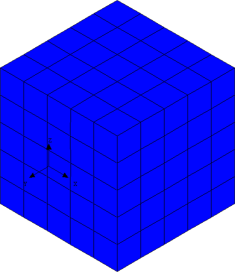

```python
i
```

Single_Crystal_A is a single crystal of RS5 super alloy orientated in phi1, Phi and phi 2 angles of 90,35.4 and 45 respectively. It consists of 5 elements in each dimension and each direction has an element length of 1.

#### Single Crystal B

```python
i = Image(image_file_scb)
```

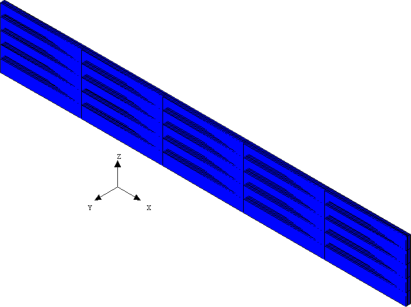

```python
i
```

Single crystal B is designed with the dimensions of the Tensile gauge in mind. It has the same number of elements as Single Crystal A and same orientation. However the length of the elements are different in each direction. The lengths are 162, 2 and 24 in the x,y and z direction respectively

#### Tensile 7A

```python
i = Image(image_file_t7a)
```

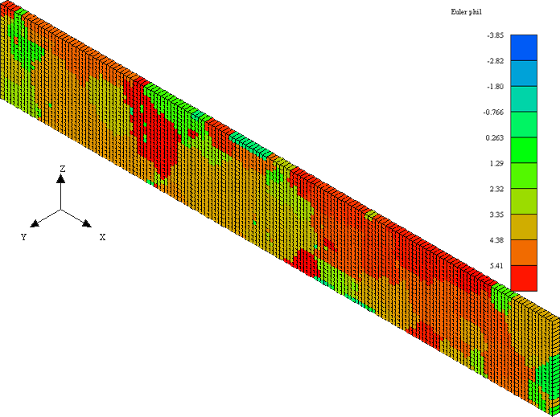

```python
i
```

#### Tensile 7B

```python
i = Image(image_file_t7b)
```

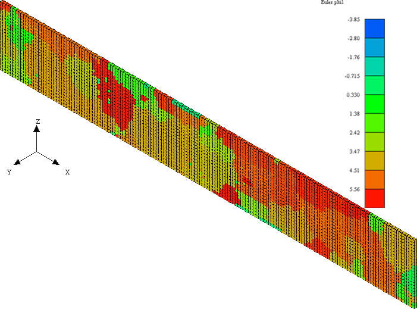

```python
i
```

Tensile 7B is only different from Tensile 7A in the lengths of elements in each direction. In this case the length of the elements are 7,0.04 and 1 in the x,y and z direction resepectively. Hence Tensile 7B has a volume of 7x 0.04 x 1 = 0.28

#### Tensile 7C

```python
i = Image(image_file_t7c)
```

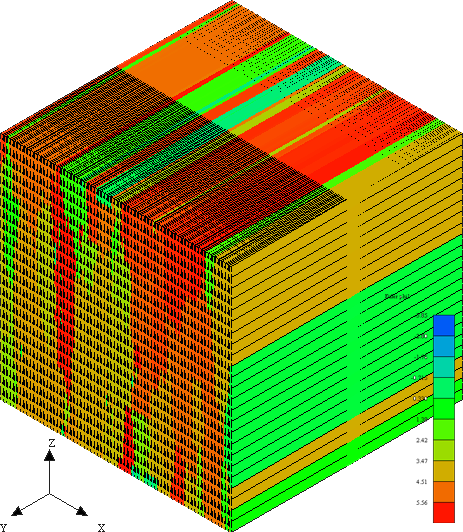

```python
i
```

Tensile 7C only varies from the above two in that the length of the elements is one in all directions.

# Results

### Single Crystal Curve

```
Reading file...
```

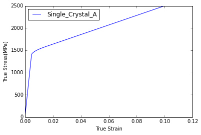

```python
fig = plt.figure()
ax = fig.add_subplot(111)
ax.grid()
extract_stress(stress_sca,1,file_name_sca)
```

```
Reading file...
```

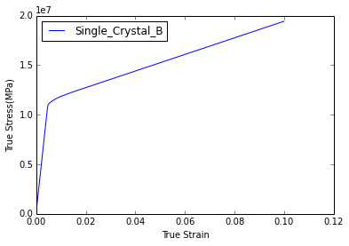

```python
fig = plt.figure()
ax = fig.add_subplot(111)
ax.grid()
extract_stress(stress_scb,1,file_name_scb)
```

```
Reading file...
```

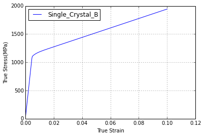

```python
fig = plt.figure()
ax = fig.add_subplot(111)
extract_stress(stress_scb,10000,file_name_scb)
```

```
Reading file...
Reading file...
```

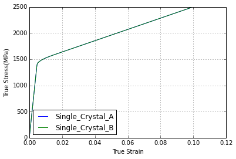

```python
fig = plt.figure()
ax = fig.add_subplot(111)
ax.grid()
for stress,value,lbl in zip([stress_sca,stress_scb],[1,7776],[file_name_sca,file_name_scb]):
    extract_stress(stress,value,lbl)
plt.show()
```

### In the case of Tensile 7...

### Experimental Tensile curve

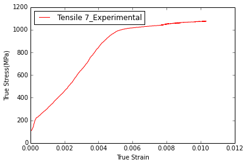

```python
fig = plt.figure()
ax = fig.add_subplot(111)
ax.grid()
for tensile_no in [7]:
    interpolate(tensile_no),true_stress_strain(tensile_no),plot_graph(tensile_no)
plt.show()
```

### Simulated Tensile Curves

#### Tensile 7A

```
Reading file...
```

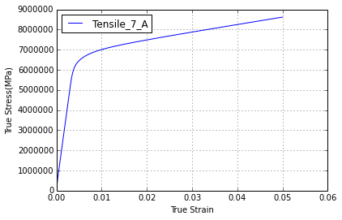

```python
fig = plt.figure()
ax = fig.add_subplot(111)
extract_stress(stress_t7a,1,file_name_t7a)
```

Very high values of stress observed. This is because the stress values have been multiplied by a factor of 7776. Hence if the values are divided by this factor the results are as shown below.

```
Reading file...
```

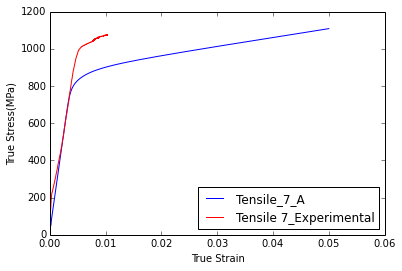

```python
fig = plt.figure()
ax = fig.add_subplot(111)
extract_stress(stress_t7a,7776,file_name_t7a)
for tensile_no in [7]:
    interpolate(tensile_no),true_stress_strain(tensile_no),plot_graph(tensile_no)
plt.show()
```

#### Tensile 7B

```
Reading file...
```

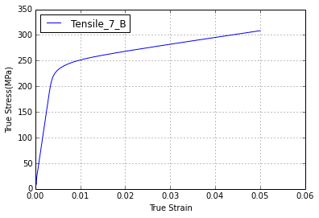

```python
fig = plt.figure()
ax = fig.add_subplot(111)
extract_stress(stress_t7b,1,file_name_t7b)
```

In this case because the total volume is 0.28 and less than 1 the tensile values have been reduced. Once the values are divided by 0.28 we get the actual values of stress as shown below

```
Reading file...
```

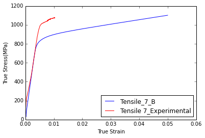

```python
fig = plt.figure()
ax = fig.add_subplot(111)
extract_stress(stress_t7b,0.28,file_name_t7b)
for tensile_no in [7]:
    interpolate(tensile_no),true_stress_strain(tensile_no),plot_graph(tensile_no)
plt.show()
```

#### Tensile 7C

```
Reading file...
```

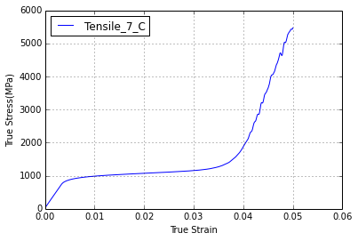

```python
fig = plt.figure()
ax = fig.add_subplot(111)
extract_stress(stress_t7c,1,file_name_t7c)
```

```
Reading file...
```

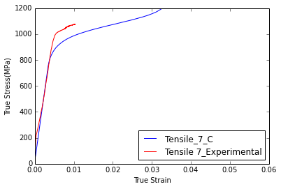

```python
fig = plt.figure()
ax = fig.add_subplot(111)
extract_stress(stress_t7c,1.0,file_name_t7c)
for tensile_no in [7]:
    interpolate(tensile_no),true_stress_strain(tensile_no),plot_graph(tensile_no)

ax.set_ylim([0,1200])
plt.show()
```

```
Reading file...
Reading file...
Reading file...
```

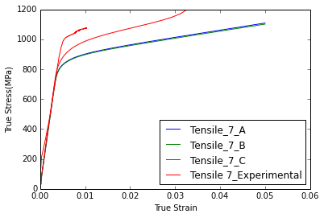

```python
fig = plt.figure()
ax = fig.add_subplot(111)
for stress,value,lbl in zip([stress_t7a,stress_t7b,stress_t7c],[7776,0.28,1],[file_name_t7a,file_name_t7b,file_name_t7c]):
    extract_stress(stress,value,lbl)
for tensile_no in [7]:
    interpolate(tensile_no),true_stress_strain(tensile_no),plot_graph(tensile_no)
ax.set_ylim([0,1200])
plt.show()
```

# Conclusion

Changing the element length scales the tensile value by the same factor that the volume is scaled up. Hence in single crystal simulations there is no effect seen.

However in polycrystalline simulation of the tensile gauge the volume used does have an effect on the calculated yield stress for the simulated gauge. When the element length is 1 in all directions and the size is not proportional to the number of elements the yield point is higher. The transistion from elastic to plastic is also broader when the mesh volume is one. However there is no difference in the simulated curves when the mesh volume is increased from 0.28 to 7776. This means that the tensile curve shape will remain consistent as long as the lengths of the elements remain proportional to the number of elements used. Both of these show a transistion from elastic to plastic that is similar to what is observed experimentally. The yield points are clearly lower than what is observed experimentally but this can be altered by increasing the crss value to between 400 and 500 (current crss value used is 350).

# Appendix A: Scripts

#### Creating Directories

```python
#folder names to access the fafrep files to obtain stress values for the different gauges

file_name_sca='Single_Crystal_A'
file_name_scb='Single_Crystal_B'
file_name_t7a='Tensile_7_A'
file_name_t7b='Tensile_7_B'
file_name_t7c='Tensile_7_C'


#directories to access the fafrep files
maindir=os.getcwd()
prein=str(maindir)+'\\Element_Length_Effects\\'+str(file_name)+'\\'+'prein.txt'
stress_scb=str(maindir)+'\\Element_Length_Effects\\'+str(file_name_scb)+'\\'+'fafrep.txt'
stress_sca=str(maindir)+'\\Element_Length_Effects\\'+str(file_name_sca)+'\\'+'fafrep.txt'
stress_t7a=str(maindir)+'\\Element_Length_Effects\\'+str(file_name_t7a)+'\\'+'fafrep.txt'
stress_t7b=str(maindir)+'\\Element_Length_Effects\\'+str(file_name_t7b)+'\\'+'fafrep.txt'
stress_t7c=str(maindir)+'\\Element_Length_Effects\\'+str(file_name_t7c)+'\\'+'fafrep.txt'

#directories to access the image files of the meshes
image_file_sca=str(maindir)+'\\Element_Length_Effects\\'+str(file_name_sca)+'\\'+'image.png'
image_file_scb=str(maindir)+'\\Element_Length_Effects\\'+str(file_name_scb)+'\\'+'image.png'
image_file_t7a=str(maindir)+'\\Element_Length_Effects\\'+str(file_name_t7a)+'\\'+'image.png'
image_file_t7b=str(maindir)+'\\Element_Length_Effects\\'+str(file_name_t7b)+'\\'+'image.png'
image_file_t7c=str(maindir)+'\\Element_Length_Effects\\'+str(file_name_t7c)+'\\'+'image.png'
```

#### Accessing the stress values from the fafrep files and plotting the stress strain curves

```python
def extract_stress(fname,x,plot_label):#x defines the scaling of the stress values due to the scaling of the volume
    data_list=[]

    f=open(fname,'r')
    print 'Reading file...'
    for line in f:
        if line[5:10] =='Power':
            xdim=float(line.split()[1])  #wherever the fafrep file says power the stress values will be extracted
            data_list.append(xdim/x)
    #plotting the graph
    strain_list=linspace(0,float(len(data_list))/float(10000),num=len(data_list))
    ax.plot(strain_list,data_list,label = str(plot_label))
    ax.grid()
    ax.legend(loc=0)
    ax.set_xlabel("True Strain")
    ax.set_ylabel("True Stress(MPa)")
    ax.hold(True)
```

#### Collecting Strain Data for DIC

```python
def read_strain(x):
    maindir=os.getcwd()
    strain_file_loc=maindir+'/Data/'
    stress_file_loc=maindir+'/Data/Tensile/'
    for file_no in  [x]:
        strain_file_name=strain_file_loc+'Tensile_'+str(file_no)+'_ASCII_Vec/*.txt'
        files=glob (strain_file_name);
        mean_strain_list=[]
        n_list=[]
        n1_list=[]
        strain_list=[]
        strain_diff_list=[]
        stress_diff_list=[]
        mid_list=[]
        #for each vector file the average macoro strain across the sample is calculated. This is for samples where
        #where the interrogation window size is 128
        for file in files:
            Vy_list=loadtxt(file)[:,3]#loading the data
            plot_data=[]
            n_list=[]
            n1_list=[]
            for n,n1 in enumerate(Vy_list):#collecting y1 and y2 to calculate eyy strain
                n_list.append(n)
                n1_list.append(n1)
            for pos,vec in zip(n_list,n1_list):
                if abs(vec)>0.001:
                    strain=abs(((Vy_list[pos+22]-vec))/1.466)
                    if strain<0.1:
                        plot_data.append(strain)
            strain_val=(average(plot_data[30:-10]))
            mean_strain_list.append(strain_val)
        return mean_strain_list
```

#### Collecting Stress Data from Tensile Rig

```python
def read_stress(x):
    maindir=os.getcwd()
    stress_file_loc=maindir+'/Data/Tensile/'
    for file_no in  [x]:#loading data from file
        stress_file_name=stress_file_loc+'T'+str(file_no)+'.txt'

    stress_data=loadtxt(stress_file_name,skiprows=7,delimiter=',')[:,3]
    corrected_data=stress_data+(0-stress_data[-1])#making correction as force is not zero in the beginning
    time_data=loadtxt(stress_file_name,skiprows=7,delimiter=',')[:,1]#time data from the same stress file
    return zip(corrected_data,time_data)
```

#### Collecting Time data from DIC data

```python
def strain_time(x):
    maindir=os.getcwd()
    strain_file_loc=maindir+'/Data/'
    for file_no in [x]:
        time_file_name=strain_file_loc+'Tensile_'+str(file_no)+'_ASCII_Time/B00001.txt'
        time_data=loadtxt(time_file_name[:])
        time_flatten=time_data.flatten()
        time=time_flatten[(len(time_flatten)/2):len(time_flatten)]-time_flatten[len(time_flatten)/2]
        time_file=strain_file_loc+'Tensile_'+str(file_no)+'_ASCII_Time/Time'+str(file_no)+'.txt'
        f=open(time_file,'w')
        f.write(time)
        f.close()
        corrected_time=time
    return corrected_time
```

#### Interpolating strain data with time data from DIC

```python
def interpolate(tensile_no):
    time=strain_time(tensile_no)
    mean_strain_list=read_strain(tensile_no)
    zi=interp1d(time[2:],mean_strain_list[2:])
    #this is done because generally the tensile rig data is 2 seconds behind the DIC data
    return zi
```

#### Interpolating the strain values with time data from tensile rig and calculating true stress and true strain

```python
def true_stress_strain(tensile_no):
    stress_time_data=read_stress(tensile_no)
    stress_list=[]
    time_data=[]
    zi=interpolate(tensile_no)

    for stress,time in stress_time_data:
        stress_list.append(stress)
        time_data.append(time)

    yi=zi(time_data[:-10])
    true_stress=[]

    for true_s,true_e in zip(stress_list[:len(yi)],yi):
        true_s=true_s*(1+true_e)
        true_stress.append(true_s)
    return zip(yi,true_stress)
```

#### Plotting True stress/strain graph

```python
def plot_graph(tensile_no):
    plot_values=true_stress_strain(tensile_no)
    true_strain=[]
    true_stress=[]
    for eyy,syy in plot_values:
        true_strain.append(eyy),true_stress.append(syy)
    ax.plot(true_strain,true_stress,'-r',label = 'Tensile '+str(tensile_no)+'_Experimental')
    ax.grid()
    ax.legend(loc=0)
    ax.set_xlabel("True Strain")
    ax.set_ylabel("True Stress(MPa)")
    ax.hold(True)
```